**CONTENT**

Simple Regression: Introduction

Regression

Assumptions regarding the random term

Expression for the coefficients of the regression

Construction of the regression as the best linear fit

Residiuals

Goodness-of-fit

Incorporating nonlinearity

Expected value and variance of the estimate

Testing

Regression through the Origin

Summary

**COURSE DETAILS**

• Simple linear regression • Multiple regression: Estimation • Multiple regression: Inference. • Further issues of OLS. • Dummy variables. • Heteroskedasticity.

Econometrics

Designed by Professor Sasha Shapoval

for New Uzbekistan University

Introduction Simple linear regression Multiple Regression

# Simple Regression: Introduction

## Regression

We are going to explain the behavior of $y$ with $x$ with a linear model \begin{equation} y = \beta_0 + \beta_1 x + u \label{e:regression} \end{equation} where $x$ and $y$ are the vectors of the data, and the vector $u$ represents the other factors that affect $y$.
If the other factors remain constant, than the changes in $y$ are fully explained by the changes in $x$: $$ \Delta y = \beta_1 \Delta x. $$ Indeed, let $(x_1, y_1, u_1)$ and $(x_2, y_2, u_2)$ are two tripples of the data such that $u_1 = u_2 = u$, i.e., $\Delta u = 0$. Equation (\ref{e:regression}) is applied twice: \begin{gather*} y_1 = \beta_0 + \beta_1 x_1 + u \\ y_2 = \beta_0 + \beta_1 x_2 + u \end{gather*} Subtracting equations we get $$ \Delta y = \beta_1 \Delta x \quad\quad \mathrm{if } \Delta u = 0. $$

**Example:**

We regress wage on the years of education: $$ \begin{equation} wage = \beta_0 + \beta_1 educ + u \label{e:wage:regr} \end{equation} $$ Then $\beta_1$ measures the change in hourly wage given another year of education, holding all other factors fixed. Some of those factors include labor force experience, innate ability, tenure with current employer, work ethic, and numerous other things.

## Assumptions regarding the random term

**$u$ is $0$ on average**  
Mathematically, it means that \begin{equation} \mathbf{E} u = 0. \label{e:zeromean} \end{equation} This assumption is not restrictive because the intercept $\beta_0$ represents a vertical shift.  
The crucial (and restrictive) assumption states that **$x$ and $u$ do not correlate**. It means that **the expected value of $u$ given $x$ does not depend on $x$**:  
\begin{equation} \mathbf{E}(u|x) = \mathbf{E}u. \label{e:meanindependenceonx} \end{equation} Combining \eqref{e:zeromean} and \eqref{e:meanindependenceonx}, we end up with a single equation \begin{equation} \mathbf{E}(u|x) = \mathbf{E}u = 0 \label{e:zerocondmean} \end{equation}

- In real problems, $u$ is typically unobserved.
- The absence of the correlation is always something to discuss

**Example:**

The score at the final exam linearly depends on the classes attended (say, in hours) and unobserved factors (such as ability):

$$ score = \beta_0 + \beta_1 attend + u. $$

Discuss whether assumption \eqref{e:zerocondmean} holds.

**Linear dependence of the expected mean on the regressor**

Takig the model equation \eqref{e:regression} and using assumption \eqref{e:zerocondmean}, compute the conditional expectation of $y$ given $x$:

\begin{equation} \mathbf{E}(y | x) = \beta_0 + \beta_1 x. \end{equation}

For any value of $x$, there is the population of the dependent variable $y | x$. The mean of the population belongs to the line $y' = \beta_0 + \beta_1 x$.

- $y$ consists of systematic part $\mathbf{E}(y | x)$
- and unsystematic part $u$

## Expression for the coefficients of the regression

$$ \hat{\beta}_1 = \frac{\sum_{i=1}^n (x_i - \bar{x})(y_i - \bar{y})} {\sum_{i=1}^n (x_i - \bar{x})^2} $$$$ \hat{\beta}_0 = \bar{y} - \hat{\beta}_1 \bar{x} $$

- independence of $u$ and $x$ in formal terms: transformation of \eqref{e:zerocondmean}:

\begin{multline} \mathbf{E}(ux) = \sum_{i,j} u_i x_j \mathbf{P}\{u = u_i, x = x_j\} = \\ \sum_{i,j} u_i x_j \mathbf{P}\{u = u_i | x = x_j\} \mathbf{P}\{x = x_j\} = \\ \sum_{j} x_j \mathbf{P}\{x = x_j\} \sum_i u_i \mathbf{P}\{u = u_i | x = x_j\} = \\ \sum_{j} x_j \mathbf{P}\{x = x_j\} \mathbf{E}\{u | x = x_j\} = \\ \big[\text{the expectation of $u$ is independent of $x_j$}\big] = \mathbf{E}x \mathbf{E}u = 0 \end{multline}

- sample $(x_i, y_i)$, $i = 1, 2, \ldots, n$
- compute the covariance of the both hand side of the regression

$$ y = \beta_0 + \beta_1 x + u $$

with $x$: $$ \mathbf{Cov}(x,y) = \beta_1 \mathbf{Cov}(x,x), $$ $$ \rho_{xy}\sigma_x\sigma_y = \beta_1 \sigma_x^2, $$ where $\rho_{xy}$ is the coefficient of the correlation between $x$ and $y$, $\sigma_x$ and $\sigma_y$ are the standard deviations. Then \begin{equation} \beta_1 = \rho_{xy}\cdot\frac{\sigma_y}{\sigma_x}. \label{e:beta1p} \end{equation}

- substitute sample for random variable characteristics in assumptions

\begin{equation} \hat{\beta}_1 = \frac{\sum_{i=1}^n (x_i - \bar{x})(y_i - \bar{y})} {\sum_{i=1}^n (x_i - \bar{x})^2} \label{e:beta1mod} \end{equation}

- Another possibility to use sample characteristics: substitution into the assumptions from the very beginning

\begin{gather} \mathbf{E}u = 0 \\ \mathbf{E}(xu) = 0 \end{gather}

or \begin{gather} \mathbf{E}(y - \beta_0 - \beta_1 x) = 0 \\ \mathbf{E}(x(y - \beta_0 - \beta_1 x)) = 0 \end{gather}

- after the substitution:

\begin{gather} \frac{1}{n}\sum_{i=1}^n (y_i - \beta_0 - \beta_1 x_i) = 0 \\ \frac{1}{n}\sum_{i=1}^n x_i(y_i - \beta_0 - \beta_1 x_i) = 0 \end{gather}

- The solution:

\begin{gather} \hat{\beta}_1 = \frac{\sum_{i=1}^n (x_i - \bar{x})(y_i - \bar{y})} {\sum_{i=1}^n (x_i - \bar{x})^2} \label{e:beta1alt} \\ \hat{\beta}_0 = \bar{y} - \hat{\beta}_1 \bar{x} \label{e:beta0} \end{gather}

Alternatively, one may write \begin{equation} \hat{\beta}_1 = \hat{\rho}_{xy} \cdot \left(\frac{\hat{\sigma}_y}{\hat{\sigma}_x}\right) \label{e:beta1mod2} \end{equation}

You see that \eqref{e:beta1mod2} coincides with \eqref{e:beta1mod}.

⚠️ **Warning:** We additionally assumed that not all $x_i$ are equal

## Construction of the regression as the best linear fit

⚠️ **Attention:** This procedure is equivalent to the above construction

**$y$ as $x$ plus noise**

- see a hidden code below

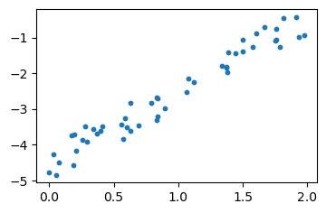

```python
import numpy as np
from numpy import random
import matplotlib.pyplot as plt
from sklearn.linear_model import LinearRegression
import scipy.stats
rng = np.random.RandomState(1)
nn = 50
fig, ax = plt.subplots(figsize=(4, 2.5))
#Generate nn = 50 normal random values and save them in x
x = 2 * rng.rand(nn)
# y[] is defined as a linear function of x[] up to a random factor
y = 2 * x - 5 + rng.rand(nn)
#plot the dependence of y on x
plt.scatter(x, y, s=10);
```

**Construction of the best fit**

- implementation of the above mathematics
- see a hidden code below

```
(-4.533652972099129, 2.0411512161387524)
```

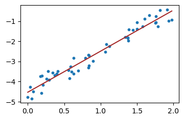

```python
beta1 = scipy.stats.pearsonr(x, y)[0] * np.std(y) / np.std(x)
beta0 = np.mean(y) - beta1 * np.mean(x)
xx = np.linspace(np.min(x), np.max(x))
yy = beta0 + beta1 * xx
fig, ax = plt.subplots(figsize=(4, 2.5))
plt.scatter(x, y, s=10)
plt.plot(xx, yy, color='brown')
beta0, beta1
```

### Residiuals

$$ u_i = y_i - \hat{y}_i = y_i - \hat{\beta}_0 - \hat{\beta}_1 x_i $$

We can formulate the problem:
what are the numbers $\beta_0$ and $\beta_1$ that minimize $$ \sum_i (y_i - \beta_0 - \beta_1 x_i)^2 $$ Prove that

- these $\beta_0$ and $\beta_1$ are the values defined above
- the sum of residuals is zero:

$$ \sum_i u_i = 0 $$

hint: recall that $\mathbf{E}u = 0$

- Other possiblities to define residuals

### Goodness-of-fit

- total sum of squares SST

$$ \mathrm{SST} = \sum_{i=1}^n (y_i - \bar{y})^2 $$

- the explained sum of squares

$$ \mathrm{SSE} = \sum_{i=1}^n (\hat{y}_i - \bar{y})^2 $$

- the residual sum of squares

$$ \mathrm{SSR} = \sum_{i=1}^n \hat{u}_i^2 $$

- Property: SST = SSE + SSR

$$ R^2 = \mathrm{SSE}/\mathrm{SST} = 1 - \mathrm{SSR}/\mathrm{SST} $$

- $R^2$ signals the quality of the fit. Lesser values of $R^2$ suggest that the quality is questionable

**computaton of SST, SSE, and SSR with the above data**

- See code below

```python
#computaton of SST, SSE, and SSR with the above data
sst = np.sum((y - np.mean(y))**2)
haty = beta0 + beta1 * x
sse = np.sum((haty - np.mean(y))**2)
u = y - haty
ssr = np.sum(u**2)
print(sst, sse, ssr, sst-sse-ssr)
```

```
81.5960501633746 77.65588083030583 3.9401693330687313 3.5083047578154947e-14
```

**Info:** There is (unexplained) distribution of $y$ for each $x$ related to $u$. A smaller variance indicates a better fit. This is measured by $R^2$

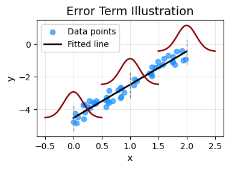

```python
import numpy as np
import matplotlib.pyplot as plt
from sklearn.linear_model import LinearRegression
# --- Data generation ---
rng = np.random.RandomState(1)
nn = 50
x = 2 * rng.rand(nn)
y = 2 * x - 5 + rng.rand(nn)
# --- Fit linear regression ---
model = LinearRegression().fit(x.reshape(-1, 1), y)
x_fit = np.linspace(0, 2, 100)
y_fit = model.predict(x_fit.reshape(-1, 1))
# Choose three equally spaced x positions
x_points = np.linspace(x_fit.min(), x_fit.max(), 3)
y_points = model.predict(x_points.reshape(-1, 1))

# --- Plot ---
fig, ax = plt.subplots(figsize=(4, 2.5))

# Scatter data
ax.scatter(x, y, color='dodgerblue', alpha=0.7, label='Data points')

# Regression line
ax.plot(x_fit, y_fit, color='black', lw=2, label='Fitted line')

# --- Gaussian-shaped "pdf" function ---
def bell_shape(center_x, center_y, width=0.3, height=0.6, n=200):
    """Returns coordinates of a Gaussian-like bell centered at (center_x, center_y)."""
    xs = np.linspace(center_x - width/2, center_x + width/2, n)
    sigma = width / 6   # roughly 3σ fits into width
    ys = center_y + height * np.exp(-0.5 * ((xs - center_x) / sigma) ** 2)
    return xs, ys

# Add hat-shaped PDFs
for xi, yi in zip(x_points, y_points):
    hx, hy = bell_shape(xi, yi, width=1.0, height=1.6)
    ax.plot(hx, hy, color='darkred', lw=1.8)
    # Add a vertical dashed line for reference
    ax.vlines(xi, yi - 0.8, yi + 0.8, color='gray', ls='--', lw=1)

# Labels and appearance
ax.set_xlabel('x', fontsize=12)
ax.set_ylabel('y', fontsize=12)
ax.set_title('Error Term Illustration', fontsize=14)
ax.legend()
ax.grid(alpha=0.3)

plt.show()
```

**Comment to question 3, the Wooldridge handbook, pages 77-78 of the file**

```python
# type
import numpy as np
y = np.array([2.8, 3.4, 3.0, 3.5, 3.6, 3.0, 2.7, 3.7])
x = np.array([21, 24, 26, 27, 29, 25, 25, 30])
```

```
0.5681318681318674 0.10219780219780222
```

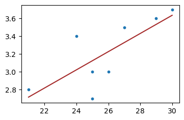

```python
from scipy.stats import pearsonr
import matplotlib.pyplot as plt
fig, ax = plt.subplots(1, 1, figsize=(4, 2.5))
beta1 = pearsonr(x, y)[0] * np.std(y) / np.std(x)
beta0 = np.mean(y) - beta1 * np.mean(x)
xx = np.linspace(np.min(x), np.max(x))
yy = beta0 + beta1 * xx
print(beta0, beta1)
plt.scatter(x, y, s=10)
plt.plot(xx, yy, color='brown')
```

```python
print(np.round(beta0, 2), np.round(beta1, 3))
```

```
0.57 0.102
```

## Incorporating nonlinearity

$$ \log(y) = \beta_0 + \beta_1 x + u $$

Another version of the model \eqref{e:wage:regr}: $$ \begin{equation} \ln(wage) = \beta_0 + \beta_1 educ + u \label{e:logwage:regr} \end{equation} $$ Now $\beta_1$ corresponds to the proportional changes in wages in response to changes in the education. If we report $100\cdot \beta_1$ then the percentage changes in hourly wages are considered.

Other standard opportunities:

$$ \begin{gather*} \log(y) = \beta_0 + \beta_1 x + u \\ y = \beta_0 + \beta_1 \log(x) + u \\ \log(y) = \beta_0 + \beta_1 \log(x) + u \end{gather*} $$

## Expected value and variance of the estimate

Theorem

The estimates $\hat{\beta}_1$ and $\hat{\beta}_0$ of $\beta_1$ and $\beta_0$ are unbiased

We place the proof only for $\hat{\beta}_1$

$\newcommand{\Exp}{\mathbf{E}}$ $\newcommand{\Var}{\mathbf{Var}}$

Proof originates from the following equation

\begin{equation} \hat{\beta}_1 = \beta_1 + \frac{\sum_{i=1}^n (x_i - \bar{x})u_i}{\sum_{i=1}^n (x_i - \bar{x})^2} \label{e:regr:beta1} \end{equation}

Indeed, we have already proved: $$ \hat{\beta}_1 = \frac{\sum_{i=1}^n (x_i - \bar{x})y_i}{\sum_{i=1}^n (x_i - \bar{x})^2} $$ Substituting $y_i = \beta_0 + \beta_1 x_i + u_i$ and opening brackets, we get \eqref{e:regr:beta1}.

> Warning: We compute the mathematical expectation with respect to $\mathrm{u}$, given the sample $\mathrm{x}$. That is why all terms $x_i-\bar{x}$ and the denominator are constants, whereas the expected value of each $u_i$ is zero, $\Exp u_i=0$

As a result, the second term in the right hand side of (\ref{e:regr:beta1}) disappears, and the estimate is unbiased

$\newcommand{\Var}{\mathbf{Var}}$

Assumption: Homoscedasticity

The variances of the random term conditional on $x$ does not depend on $i$: $$ \Var(u_i \,|\, x) = \sigma^2 $$

$\newcommand{\Exp}{\mathbf{E}}$ $\newcommand{\Var}{\mathbf{Var}}$

Theorem

The variance of the estimates $\hat{\beta}_1$ is $$ \Var(\hat{\beta}_1) = \frac{\sigma^2}{\Sigma_{xx}}, \quad\text{where}\quad \Sigma_{xx} = \sum_{i=1}^n (x_i - \bar{x})^2 $$

Proof is based on the same equation

$$ \hat{\beta}_1 = \beta_1 + \frac{\sum_{i=1}^n (x_i - \bar{x})u_i}{\Sigma_{xx}} $$

Recall that the computation is performed under assumption that the sample is fixed (but $u$ is random). Then $$ \Var(\hat{\beta}_1) = \frac{1}{\Sigma_{xx}^2} \sum_{i=1}^n (x_i - \bar{x})\Var(u_i) = \frac{1}{\Sigma_{xx}^2} \Sigma_{xx} \sigma^2 = \frac{\sigma^2}{\Sigma_{xx}} $$

$t$-distribution of the standartazied estimator

In practice, the variance of the estimator is not known. A natural estimate of the variance appears when the variance $\sigma^2$ of the errors is estimated with the data. Let $\hat{s}^2$ be this estimate.

⚠️ **Recalling:** This estimate exploits **residuals**: $$ \hat{u}_i = y_i - \hat{y}_i = y_i - \hat{\beta}_0 - \hat{\beta}_1 x_i. $$

The unbiased estimator of the variance of the estimator is:

$$ \hat{s}^2 = \frac{1}{n - 2} \sum_{i=1}^n \hat{u}_i^2 = \frac{1}{n - 2} \sum_{i=1}^n (y_i - \hat{\beta}_0 - \hat{\beta}_1 x_i)^2. $$

We divide by $n - 2$ because we estimated **two parameters** ($\beta_0$, $\beta_1$) from the data.

Then we introduce the standard error $se$, using estimator $\big(se(\hat{\beta}_1)\big)^2$ for variance of $\hat{\beta}_1$, as $$ \big(se(\hat{\beta}_1)\big)^2 = \frac{\hat{s}^2}{\Sigma_{xx}}, $$

🔔 Normality assumption

Assume additionally that the error term is normally distributed conditional on the regressors: $$ u_i \mid X \sim \mathcal{N}(0, \sigma^2). $$

Theorem

The random variable $$ \frac{\hat{\beta}_1 - \beta_1}{se(\hat{\beta}_1)} \sim t_{n-2}, $$ where $n$ is the sample volume, follows $t$-distribution with $n - 2$ degrees of freedom. The reduction by $2$ is explained by the existence of the two model parameters, the slope and the intercept, that are estimated with the regression.

$\newcommand{\Prob}[1]{\mathsf{P}\{#1\}}$

## Testing

$H_0$: $\beta_1 = 0$ against $H_1$: $\beta_1 > 0$

“Well,” said Owl, “the customary procedure in such cases is as follows.”

“What does Crustimoney Proseedcake mean?” said Pooh. “For I am a Bear of Very Little Brain, and long words Bother me.”

“It means the Thing to Do.”

- Alternative hypothesis: $\beta_1 > 0$
- Significance level: $\alpha = 5\%$
- Rule: compute $t$-statistics

if the probability $\Prob{X > t_{\hat{\beta}_1}} < \alpha$, i.~e., the $t$-statistics is so large that larger values are extremely rare (with respect to the chosen significance level), reject the null hypothesis.

- The inequality in probabilities is equivalent to the fact that the $t$-statistics is larger than the $\alpha$-quantile:

$$ t_{\hat{\beta}_j} > q_{\alpha, n-2}, $$

where the quantile can be found in the corresponding table (taking into account the number of freedom $n-2$)

```python
#the above example example (several slides ago)
#$H_1$ is two-sided
y = np.array([2.8, 3.4, 3.0, 3.5, 3.6, 3.0, 2.7, 3.7])
x = np.array([21, 24, 26, 27, 29, 25, 25, 30])
from scipy.stats import pearsonr
import matplotlib.pyplot as plt
beta1 = pearsonr(x, y)[0] * np.std(y) / np.std(x)
beta0 = np.mean(y) - beta1 * np.mean(x)
#confidence interval and hypothesis testing
from scipy.stats import t
import numpy as np
y_hat = [beta0 + beta1*x_cur for x_cur in x]
u_hat = [y[i] - y_hat[i] for i in range(len(y))]
u_hat_std = np.std(u_hat) #sum of squared residuals (SSR)
sigma_xx = 0 #total variation in x
xmean = np.array(x).mean()
u_std_est = 0
for x_cur, y_cur in zip(x, y):
    sigma_xx += (x_cur - xmean)**2
    u_std_est += (y_cur - beta0 - beta1*x_cur)**2
df = len(y)-2 #degree of freedom
u_std_est = np.sqrt(u_std_est/df)
t_statistics = beta1 / u_std_est * np.sqrt(sigma_xx)
tmp = t.cdf(t_statistics, df)
'''Double the smaller tail trick: if t-statistic is negative, double the left tail; otherwise - the right tail
'''
if tmp < 0.5:
    pvalue = 2*tmp
else:
    pvalue = 2*(1-tmp)
print('statistics = {:.3f}'.format(t_statistics), 'p-value = ', '{:e}'.format(pvalue),
      'df = {:.2f}'.format(df))
#confidence interval at a given significance level
alph = [0.005, 0.01] #two levels of significance
for a in alph: #for each significance level
    t_crit = t.ppf(1 - a/2, df)  # two-sided critical value
    lower = beta1 - t_crit * u_std_est / np.sqrt(sigma_xx)
    upper = beta1 + t_crit * u_std_est / np.sqrt(sigma_xx)
    print(f"significance level = {a}; CI = [{lower:.3f}, {upper:.3f}]")
```

```
statistics = 2.863 p-value =  2.867660e-02 df = 6.00
significance level = 0.005; CI = [-0.052, 0.256]
significance level = 0.01; CI = [-0.030, 0.235]
```

## Regression through the Origin

Given $\Exp(y | x=0 ) = 0$, the regression is

$$ y = \beta_1 x + u $$

With same assumptions on $u$, the estimate $\tilde{\beta}_1$ of $\beta_1$ is

$$ \tilde{\beta}_1 = \frac{\sum_{i=1}^n x_i y_i}{\sum_{i=1}^n x_i^2} $$

**Prove, using single-variable calculus**

## Summary

Next: Multiple Regression

Course homepage  
Distributed under a Creative Commons Attribution-NonCommercial-ShareAlike 4.0 International (CC BY-NC-SA 4.0) license